# Tensorflow Project

Using the [Bank Authentication Data Set](https://archive.ics.uci.edu/ml/datasets/banknote+authentication) from the UCI repository.

The data consists of 5 columns:

- variance of Wavelet Transformed image (continuous)
- skewness of Wavelet Transformed image (continuous)
- curtosis of Wavelet Transformed image (continuous)
- entropy of image (continuous)
- class (integer)

Where class indicates whether or not a Bank Note was authentic.

## Get the Data

```python
import pandas as pd
```

```python
data= pd.read_csv('bank_note_data.csv')
```

**Check the head of the Data**

```python
data.head()
```

|  | Image.Var | Image.Skew | Image.Curt | Entropy | Class |
| --- | --- | --- | --- | --- | --- |
| 0 | 3.62160 | 8.6661 | -2.8073 | -0.44699 | 0 |
| 1 | 4.54590 | 8.1674 | -2.4586 | -1.46210 | 0 |
| 2 | 3.86600 | -2.6383 | 1.9242 | 0.10645 | 0 |
| 3 | 3.45660 | 9.5228 | -4.0112 | -3.59440 | 0 |
| 4 | 0.32924 | -4.4552 | 4.5718 | -0.98880 | 0 |

## EDA

**Importing seaborn and set matplolib inline for viewing**

```python
import seaborn as sns
%matplotlib inline
```

**Creating a Countplot of the Classes (Authentic 1 vs Fake 0)**

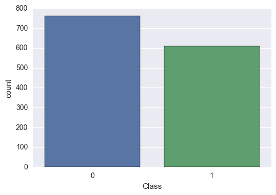

```python
sns.countplot(x='Class',data = data)
```

**Creating a PairPlot of the Data with Seaborn, set Hue to Class**

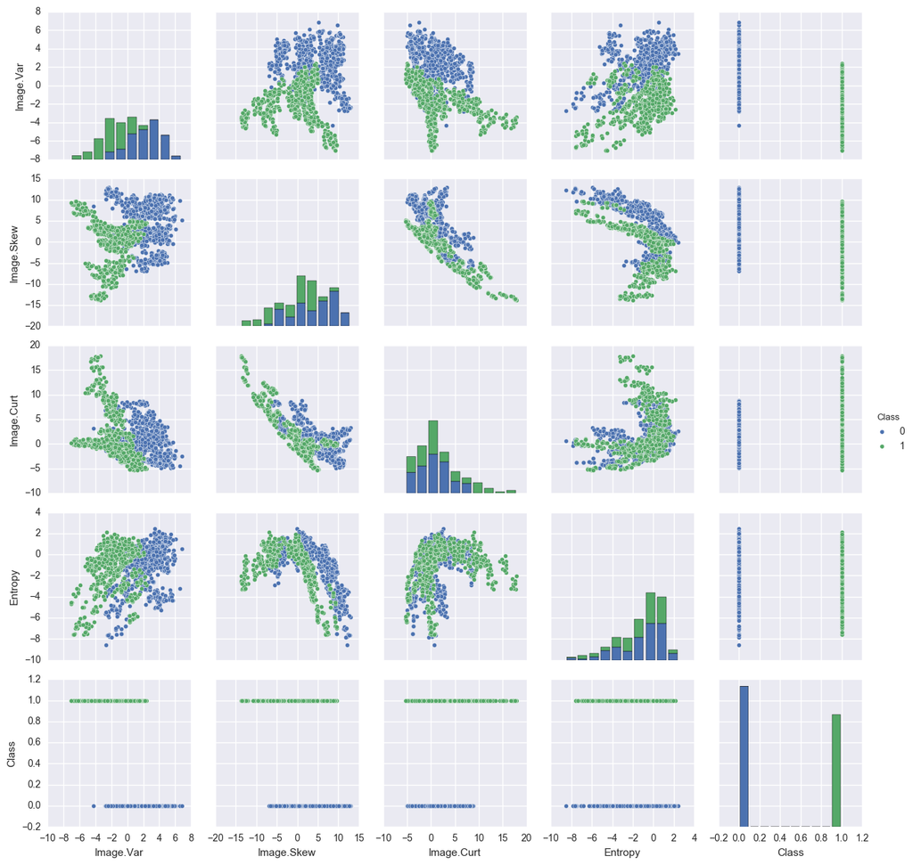

```python
sns.pairplot(data,hue='Class')
```

## Data Preparation

### Standard Scaling

**Import StandardScaler() from SciKit Learn**

```python
from sklearn.preprocessing import StandardScaler
```

**Create a StandardScaler() object called scaler.**

```python
scaler = StandardScaler()
```

**Fit scaler to the features.**

```python
scaler.fit(data.drop('Class',axis=1))
```

```
StandardScaler(copy=True, with_mean=True, with_std=True)
```

**Use the .transform() method to transform the features to a scaled version.**

```python
scaled_features = scaler.fit_transform(data.drop('Class',axis=1))
```

**Convert the scaled features to a dataframe and check the head of this dataframe to make sure the scaling worked.**

```python
df_feat = pd.DataFrame(scaled_features,columns=data.columns[:-1])
df_feat
```

|  | Image.Var | Image.Skew | Image.Curt | Entropy |
| --- | --- | --- | --- | --- |
| 0 | 1.121806 | 1.149455 | -0.975970 | 0.354561 |
| 1 | 1.447066 | 1.064453 | -0.895036 | -0.128767 |
| 2 | 1.207810 | -0.777352 | 0.122218 | 0.618073 |
| 3 | 1.063742 | 1.295478 | -1.255397 | -1.144029 |
| 4 | -0.036772 | -1.087038 | 0.736730 | 0.096587 |
| 5 | 1.384604 | 1.320874 | -1.243653 | -0.938386 |
| 6 | 1.111108 | 0.185881 | -0.155217 | 0.836028 |
| 7 | 0.583612 | -1.488408 | 1.640023 | 0.280680 |
| 8 | 0.974571 | 0.653913 | -0.499268 | 0.275752 |
| 9 | 0.387745 | 1.236571 | -0.851680 | 0.217263 |
| 10 | 0.278340 | 1.168511 | -0.838148 | 0.183401 |
| 11 | 1.251410 | -0.788994 | 0.231399 | 0.978250 |
| 12 | 0.515730 | 0.978394 | -0.288662 | -0.913770 |
| 13 | -0.707505 | 1.520502 | 0.266586 | -0.830637 |
| 14 | 1.045232 | 1.159682 | -1.018723 | 0.294840 |
| 15 | 1.493024 | -0.905392 | 0.485550 | 1.270687 |
| 16 | 0.787607 | 0.194693 | -0.238147 | 0.846494 |
| 17 | 0.130137 | 0.157655 | 0.683834 | 0.853879 |
| 18 | 0.356883 | -1.159342 | 1.611985 | -0.436588 |
| 19 | 1.692128 | 1.551899 | -1.334729 | -1.385381 |
| 20 | 1.883702 | 1.017205 | -0.932405 | 0.335473 |
| 21 | -0.036786 | -1.087038 | 0.736730 | 0.096587 |
| 22 | 1.232513 | 1.404462 | -1.211832 | -1.345338 |
| 23 | 0.176690 | 1.186851 | -0.715042 | -0.222947 |
| 24 | 1.407618 | 1.357555 | -1.410511 | -1.217306 |
| 25 | 0.095704 | -1.264798 | 1.610593 | -0.799831 |
| 26 | 0.249660 | -0.965356 | 0.970201 | 0.264672 |
| 27 | -0.287105 | 1.102548 | 0.177505 | -1.213592 |
| 28 | 2.156986 | 1.345913 | -1.348261 | -0.968526 |
| 29 | 1.568365 | -0.900091 | 0.469442 | 1.086613 |
| ... | ... | ... | ... | ... |
| 1342 | -0.767715 | -1.320176 | 1.038021 | 1.144464 |
| 1343 | -0.490183 | -1.471841 | 0.832797 | 0.723970 |
| 1344 | 0.320708 | -0.287454 | -0.760394 | 1.198648 |
| 1345 | 0.631364 | 0.370339 | -1.439338 | -0.437826 |
| 1346 | 0.289776 | 0.502948 | -1.551303 | -2.229472 |
| 1347 | -2.047852 | 1.227060 | -0.421709 | -2.250422 |
| 1348 | -1.200797 | 0.071954 | -0.202150 | 0.376111 |
| 1349 | -0.710426 | -0.695179 | 0.072084 | 0.996719 |
| 1350 | -0.229655 | -0.703293 | -0.346534 | 0.836028 |
| 1351 | 0.311277 | -0.003520 | -1.092903 | 0.598371 |
| 1352 | 0.371557 | 0.256770 | -1.259970 | -0.111531 |
| 1353 | -0.111839 | 0.221505 | -1.120546 | -0.787547 |
| 1354 | -1.346412 | 0.244430 | -0.491514 | -1.110176 |
| 1355 | -2.321453 | 1.156870 | -0.374574 | -1.163122 |
| 1356 | -1.587885 | 0.170711 | -0.122403 | 0.256049 |
| 1357 | -1.064013 | -0.394322 | -0.107488 | 0.771993 |
| 1358 | -0.508612 | -0.360110 | -0.534668 | 0.568818 |
| 1359 | -0.129360 | 0.096993 | -1.006793 | 0.271443 |
| 1360 | -0.239708 | 0.002462 | -0.897613 | 0.184015 |
| 1361 | -0.706238 | -0.146372 | -0.489722 | 0.168007 |
| 1362 | -0.915125 | -0.056086 | -0.313919 | -0.231565 |
| 1363 | -0.563191 | -0.570327 | 0.354297 | 0.882204 |
| 1364 | -1.151707 | -1.457728 | 2.109170 | 0.366874 |
| 1365 | -1.737794 | -1.318404 | 2.202428 | 0.315771 |
| 1366 | -1.000707 | 0.310376 | -0.417731 | -0.049348 |
| 1367 | -0.009711 | -0.097693 | -0.660962 | 0.300996 |
| 1368 | -0.641313 | -1.158984 | 1.179023 | 0.730127 |
| 1369 | -1.472357 | -2.621646 | 3.759017 | -0.754884 |
| 1370 | -1.406693 | -1.756471 | 2.552043 | -0.043158 |
| 1371 | -1.047122 | -0.439822 | 0.298616 | 1.136464 |

1372 rows × 4 columns

## Train Test Split

**Create two objects X and y which are the scaled feature values and labels respectively.**

```python
X = df_feat
```

```python
y = data['Class']
```

**Using the .as_matrix() method on X and Y and reset them equal to this result. We need to do this in order for TensorFlow to accept the data in Numpy array form instead of a pandas series.**

```python
import numpy as np
X = X.as_matrix()
y = y.as_matrix()
```

**Use SciKit Learn to create training and testing sets of the data:**

```python
from sklearn.cross_validation import train_test_split
```

```python
X_train, X_test, y_train, y_test = train_test_split(X, y, test_size=0.3)
```

# Contrib.learn

```python
import tensorflow as tf
feature_columns = tf.contrib.learn.infer_real_valued_columns_from_input(X_train)
```

```
WARNING:tensorflow:float64 is not supported by many models, consider casting to float32.
```

**Create an object called classifier which is a DNNClassifier from learn. Set it to have 2 classes and a [10,20,10] hidden unit layer structure:**

```python
classifier = tf.contrib.learn.DNNClassifier(feature_columns=feature_columns, hidden_units=[10, 20, 10], n_classes=2)
```

[output not shown]

**Now fit classifier to the training data.**

```python
classifier.fit(X_train, y_train, steps=200, batch_size=20)
```

[output not shown]

[output not shown]

[output not shown]

## Model Evaluation

**Use the predict method from the classifier model to create predictions from X_test**

```python
note_predictions = list(classifier.predict(X_test, as_iterable=True))
```

[output not shown]

**Now create a classification report and a Confusion Matrix.**

```python
from sklearn.metrics import classification_report,confusion_matrix
```

```python
print(confusion_matrix(y_test,note_predictions))
```

```
[[226   0]
 [  0 186]]
```

```python
print(classification_report(y_test,note_predictions))
```

```
             precision    recall  f1-score   support

          0       1.00      1.00      1.00       226
          1       1.00      1.00      1.00       186

avg / total       1.00      1.00      1.00       412
```

```python
from sklearn import metrics
score = metrics.accuracy_score(y_test,note_predictions)
print('Accuracy: {0:f}'.format(score))
```

```
Accuracy: 1.000000
```

## Comparison

**Use SciKit Learn to Create a Random Forest Classifier and compare the confusion matrix and classification report to the DNN model**

```python
from sklearn.ensemble import RandomForestClassifier
```

```python
rfc = RandomForestClassifier(n_estimators=200)
```

```python
rfc.fit(X_train,y_train)
```

```
RandomForestClassifier(bootstrap=True, class_weight=None, criterion='gini',
            max_depth=None, max_features='auto', max_leaf_nodes=None,
            min_samples_leaf=1, min_samples_split=2,
            min_weight_fraction_leaf=0.0, n_estimators=200, n_jobs=1,
            oob_score=False, random_state=None, verbose=0,
            warm_start=False)
```

```python
rfc_preds = rfc.predict(X_test)
```

```python
print(classification_report(y_test,rfc_preds))
```

```
             precision    recall  f1-score   support

          0       1.00      0.98      0.99       226
          1       0.98      0.99      0.99       186

avg / total       0.99      0.99      0.99       412
```

```python
print(confusion_matrix(y_test,rfc_preds))
```

```
[[222   4]
 [  1 185]]
```

**Here DNN Classifier is better at classifying than RandomForest.**